# Intro to R

Applied Machine Learning in Economics

At the end of the day, scientific programming languages are just dressed up calculators. `R` is one of them. We can easy perform commands such as `1+1` and `R` will output `2`. They are dressed up in the sense that they can perform much more complicated operations than the calculator on your phone (how long until this reference is outdated?). Consequently, this requires input to be given in code.

`R` is an object oriented programming language. What this means is that it stores its variables as objects. You can think of this like storing things in boxes in your kitchen, where you will work with it. Some boxes may have numbers in them, where others could have letters.

# 1 Different R Classes

## 1.1 `character`

The first thing to do with any programming language is to bring it to life!

```r
print("Hello world!") # Brings R to life!
```

```
## [1] "Hello world!"
```

What we just did was print a string of letters and punctuation, know in `R` as a `character` class. We typically wrap these with double quotes (`"`), but this can also be done with single quote (`'`) to produce the following:

```r
print('"Hello world!" says R.')
```

```
## [1] "\"Hello world!\" says R."
```

## 1.2 `numeric` and `integer`

Which brings us to numbers. There are two classes for numbers: `integer` and `numeric`. `numeric`s stores information before *and* after the period, where `integer`s only store information before the period.

```r
class(2.1)
```

```
## [1] "numeric"
```

```r
class(2L)
```

```
## [1] "integer"
```

```r
class(2)
```

```
## [1] "numeric"
```

There are some other numbers you may not have thought about:

```r
class(Inf)
```

```
## [1] "numeric"
```

```r
Inf/Inf
```

```
## [1] NaN
```

```r
class(NaN) # Not a number
```

```
## [1] "numeric"
```

## 1.3 `logical`

There are Booleans or `logical` objects, which simply means true or false. You can either type out `TRUE` and `FALSE` or `T` and `F`.

```r
class(TRUE)
```

```
## [1] "logical"
```

But true and false is really just another way to say one or zero. Can’t remember which one is which? Try this:

```r
T*1
```

```
## [1] 1
```

We can negate Booleans with an `!`.

```r
!T
```

```
## [1] FALSE
```

You will often come across `NA`s, which is an abbreviation for **not available**. They denote missing data. It is not uncommon to find datasets that do not have observations for every variable.

```r
class(NA)
```

```
## [1] "logical"
```

They will also mess up your math!

```r
NA*1
```

```
## [1] NA
```

## 1.4 `NULL`

`NULL`s are empty objects. They have zero length. I use them when I am initializing objects, but don’t want to store anything in them initially (haha).

```r
length(NULL)
```

```
## [1] 0
```

```r
class(NULL)
```

```
## [1] "NULL"
```

```r
NULL*1 # Produces an empty numeric
```

```
## numeric(0)
```

# 2 Different `R` Objects

As I mentioned above, R is an object oriented language. There are several different types of objects in R. Let’s make a few, shall we?

## 2.1 Values

```r
a = 4
b = 90
```

Running this inside of R will show them in the top right of you global environment. You can perform math on these objects:

```r
a*b
```

```
## [1] 360
```

You have a significant amount of freedom while naming objects. However, there are a few criteria

- Must begin with a letter (upper or lowercase)
- Can have numbers in them
- Can use a `.` or a `_`

Let’s give an example:

```r
name4_1Weird0.Example = a+b
```

We can even define lots of objects at the same time if we want them to have the same value!

```r
the = same = value = 117
```

Now that we have had some fun making these objects, we can print them out into the console using `ls()`.

```r
ls()
```

```
## [1] "a"                     "b"                     "name4_1Weird0.Example"
## [4] "same"                  "the"                   "value"
```

If we don’t like what we see, we can remove them using `rm()`

```r
rm(name4_1Weird0.Example, value)
```

And then check to see if it worked

```r
ls()
```

```
## [1] "a"    "b"    "same" "the"
```

Well would you look at that!

If we are really getting adventurous, we can make objects that have multiple elements using `R`s concatenate function.

```r
multi = c(4,9,0)
```

Much like single element object, we can perform math on this too!

```r
multi^2
```

```
## [1] 16 81  0
```

But this does come with a caveat. The objects we are concatenating or merging together must be of the same class. As you can see below, merging together a `numeric` with a `character` produces a `character` object. This indicated by the quotes being around the elements.

```r
c('econ', 490)
```

```
## [1] "econ" "490"
```

Sad.

## 2.2 `list`

But what if we want to force it? Can you guess what type of object we will need to use? That’s right! It is a `list`! How did you know?!

```r
class
```

```
## function (x)  .Primitive("class")
```

```r
class = list('econ', 490)
class
```

```
## [[1]]
## [1] "econ"
##
## [[2]]
## [1] 490
```

```r
class(class) # You can name objects as functions. I would advise against this, however.
```

```
## [1] "list"
```

You could make lists with any combination of `numeric`s, `character`s, `matrix`s, `data.frame`s, or even `list`s!

Speaking of matrices…

## 2.3 `matrix`

Let’s create a 2$$3 matrix with the a top row of 1, 2, 3 and the bottom of 4, 5, 6.

```r
matrix(1, 2, 3,
       4, 5, 6)
# Error in matrix(1, 2, 3, 4, 5, 6) : unused argument (6)
```

Well that didn’t work… Oh right! We have to use concatenate!

```r
matrix(c(1, 2, 3,
         4, 5, 6))
```

```
##      [,1]
## [1,]    1
## [2,]    2
## [3,]    3
## [4,]    4
## [5,]    5
## [6,]    6
```

Well, that still isn’t correct. Maybe we need a bit of help. Let’s try searching the **help page** for matrix. Go ahead and type out `?matrix` in your console (the bottom left window).

Ah, so that’s the issue. We need to specify that we want a 2$$3 matrix. But since we are supplying 6 values, we only need to specify either `nrow` or `ncol` because `R` can do the math to figure out what is missing. We will also need to specify the argument `byrow = T`.

```r
m = matrix(c(1,2,3,4,5,6), nrow = 2, byrow = T)
m
```

```
##      [,1] [,2] [,3]
## [1,]    1    2    3
## [2,]    4    5    6
```

Much better!

## 2.4 `data.frame`

Now we are getting into the good stuff. Behold, the data frame!

```r
data.frame(m)
```

```
##   X1 X2 X3
## 1  1  2  3
## 2  4  5  6
```

```r
df = data.frame(m)
df$X2
```

```
## [1] 2 5
```

Woah! You can grab specific variables by name!

Which brings us to indexing. This is when we want to grab specific slices of our $\pi$, I mean data. You select the *i*th row first, and the *jth* column second. Remember this mnemonic for which comes first: “*I* can row a boat, but *j* cannot”.

Let’s do some selection. How about the second row and first two columns.

```r
df[2, c(1:2)]
```

```
##   X1 X2
## 2  4  5
```

Notice the `:`? This creates an object that includes all integers from the first number to the last. Try this out on your own computer: `4:90`.

Because we are dealing with a `data.frame` and not a `matrix`, we can call the columns by name like so.

```r
df[2, c('X1', 'X2')]
```

```
##   X1 X2
## 2  4  5
```

```r
df[2, ]
```

```
##   X1 X2 X3
## 2  4  5  6
```

We can also generate data frames from scratch. Let’s create a data frame that has a variable called `state` that represents each state by using `1:50` and a `year` variable for 1776. Note that instead of `1:50`, we will be using the `seq()` function.

```r
ex_df = data.frame(states = seq(1, 50), year = 1776) # #U.S.A
```

This data set is now approaching to be too big to just print. so let’s just take a look at the top 6 rows, and the bottom 3 rows.

```r
head(ex_df)
```

```
##   states year
## 1      1 1776
## 2      2 1776
## 3      3 1776
## 4      4 1776
## 5      5 1776
## 6      6 1776
```

```r
tail(ex_df, 3)
```

```
##    states year
## 48     48 1776
## 49     49 1776
## 50     50 1776
```

You know what my favorite part of this example is? There were absolutely not 50 states in 1776. MUWAHAHAHA!

Anyway… We can add on additional variables using our good ol’ friend `$`

```r
ex_df$in_us = TRUE
```

Well, I certainly had fun creating all of these wonderful and lovely objects! What about you?

No?

Oh.

Well, then I suppose we should just get rid of everything then.

```r
ls()
```

```
## [1] "a"     "b"     "class" "df"    "ex_df" "m"     "multi" "same"  "the"
```

```r
rm(list = ls())
ls()
```

```
## character(0)
```

# 3 Logic Statements

In order to select specific parts of my data, I am *always* using logic statements. We will get to how to do this in subsequent lectures, but let’s just do some examples for now.

Equality, or not!

```r
1 == 3
```

```
## [1] FALSE
```

```r
1 != 3
```

```
## [1] TRUE
```

Much like negating `logical` objects, we use a `!` to negate equality checks. This must go in front of `=`.

We can also check for strict or weak inequality. When we want weak inequality, we say **greater** than or **equal** to, which is exactly the order we code it out.

```r
1 < 3 # strict inequality
```

```
## [1] TRUE
```

```r
1 >= 3 # weak inequality
```

```
## [1] FALSE
```

We can then do *many to one* comparisons.

```r
3 == c(1,2,3) # order doesn't matter
```

```
## [1] FALSE FALSE  TRUE
```

Or we can do *one to many* comparisons, that is, seeing if an object is in another.

```r
1 %in% c(1,2,3)
```

```
## [1] TRUE
```

If we want to negate an `%in%` check, the `!` needs to go in front. In theory this works for negating a `==` or inequality statements. But in practice that involves typing more, so I only do it when I have to, like with the `%in%` functions.

```r
!1 %in% c(1,2,3)
```

```
## [1] FALSE
```

# 4 Loops

Loops are particularly useful for tedious repetitive tasks. This is where the *programming* capabilities of our calculator named `R` can really come in handy. I am just going to show you a toy example of a `for` loop that requires an `if` statement.

```r
set.seed(117) # so you can replicate this at home
n = 10
j = rnorm(n, mean = 1, sd = 2^4)

for(i in 1:n){
  if(j[i] >= 1){print('master')}
  # else if(j[i] < 1)  This line is redundant, so it is commented out
  else{
    print('chief')
  }
}
```

```
## [1] "master"
## [1] "master"
## [1] "master"
## [1] "chief"
## [1] "chief"
## [1] "chief"
## [1] "master"
## [1] "chief"
## [1] "master"
## [1] "master"
```

# 5 Loading Data

The two most common types of data files are `.csv` and `.txt`. The first is are “comma separated values” where the latter are tab separate values. Open one up with notepad, or whatever the Apple equivalent sometime is to see what I am talking about.

To load in data, we need to tell `R` where it is stored in our computer (where in the basement did we store this box so `R` can bring it to the kitchen?). We will be using the Gap Minder data, which collects life expectancy, GDP per capita, and population for many different countries over several years. We will just be using the 2007 data. See the course website for the file.

**For Windows Users**

1. Open the file location in File Explorer
2. Right click the file
3. Properties
4. Highlight and copy the path to your clipboard (`Ctrl-C`)
5. Be patient a sec for me to explain this to the Apple users… I am not biased ;)

**For** *inferior-but-we-can-still-be-friends* **Mac Users**

```r
# Our clipboard will show this
# C:\Users\johnj\Documents\Data\Applied ML ECON490\lecture data
# But R HATES backslashes so we need forward slashes.
# Put it into read.csv() as shown below
#    Ctrl-f
#       put a \ in find
#       put a  / in replace
#       click all
# type out a / followed by the name of the file
gm = read.csv('C:/Users/johnj/Documents/Data/Applied ML ECON490/lecture data/gapminder_2007.csv')
```

A good first step after loading in the data is to do some exploration.

```r
names(gm) # The names of the variables
```

```
## [1] "continent" "country"   "year"      "gdpPercap" "lifeExp"   "pop"
```

```r
str(gm)   # the structure (dimension of data & class of variables)
```

```
## 'data.frame':    142 obs. of  6 variables:
##  $ continent: chr  "Africa" "Africa" "Africa" "Africa" ...
##  $ country  : chr  "Algeria" "Angola" "Benin" "Botswana" ...
##  $ year     : int  2007 2007 2007 2007 2007 2007 2007 2007 2007 2007 ...
##  $ gdpPercap: num  6223 4797 1441 12570 1217 ...
##  $ lifeExp  : num  72.3 42.7 56.7 50.7 52.3 ...
##  $ pop      : int  33333216 12420476 8078314 1639131 14326203 8390505 17696293 4369038 10238807 710960 ...
```

```r
summary(gm) # some nice summary statics
```

```
##   continent           country               year        gdpPercap
##  Length:142         Length:142         Min.   :2007   Min.   :  277.6
##  Class :character   Class :character   1st Qu.:2007   1st Qu.: 1624.8
##  Mode  :character   Mode  :character   Median :2007   Median : 6124.4
##                                        Mean   :2007   Mean   :11680.1
##                                        3rd Qu.:2007   3rd Qu.:18008.8
##                                        Max.   :2007   Max.   :49357.2
##     lifeExp           pop
##  Min.   :39.61   Min.   :1.996e+05
##  1st Qu.:57.16   1st Qu.:4.508e+06
##  Median :71.94   Median :1.052e+07
##  Mean   :67.01   Mean   :4.402e+07
##  3rd Qu.:76.41   3rd Qu.:3.121e+07
##  Max.   :82.60   Max.   :1.319e+09
```

```r
head(gm);tail(gm)
```

```
##   continent      country year  gdpPercap lifeExp      pop
## 1    Africa      Algeria 2007  6223.3675  72.301 33333216
## 2    Africa       Angola 2007  4797.2313  42.731 12420476
## 3    Africa        Benin 2007  1441.2849  56.728  8078314
## 4    Africa     Botswana 2007 12569.8518  50.728  1639131
## 5    Africa Burkina Faso 2007  1217.0330  52.295 14326203
## 6    Africa      Burundi 2007   430.0707  49.580  8390505
```

```
##     continent        country year gdpPercap lifeExp      pop
## 137    Europe         Sweden 2007 33859.748  80.884  9031088
## 138    Europe    Switzerland 2007 37506.419  81.701  7554661
## 139    Europe         Turkey 2007  8458.276  71.777 71158647
## 140    Europe United Kingdom 2007 33203.261  79.425 60776238
## 141   Oceania      Australia 2007 34435.367  81.235 20434176
## 142   Oceania    New Zealand 2007 25185.009  80.204  4115771
```

I want to know what continents we have data for, but I don’t want to clog my console with output. I wonder if there is a function for that…

```r
unique(gm$continent)
```

```
## [1] "Africa"   "Americas" "Asia"     "Europe"   "Oceania"
```

Well that certainly isn’t the 7 continents I know and love…

I wonder how many observations we have for each continent.

```r
sort(table(gm$continent))
```

```
##
##  Oceania Americas   Europe     Asia   Africa
##        2       25       30       33       52
```

# 6 EDA

As you will find out in the data science world, the is a boat load of marketing going on. By the end of the course I hope you have learned that machine learning is just a fancy phrase for statistics. They also have another fancy phrase: Exploratory Data Analysis. Well that sounds mystifying and magical. Let’s do some!

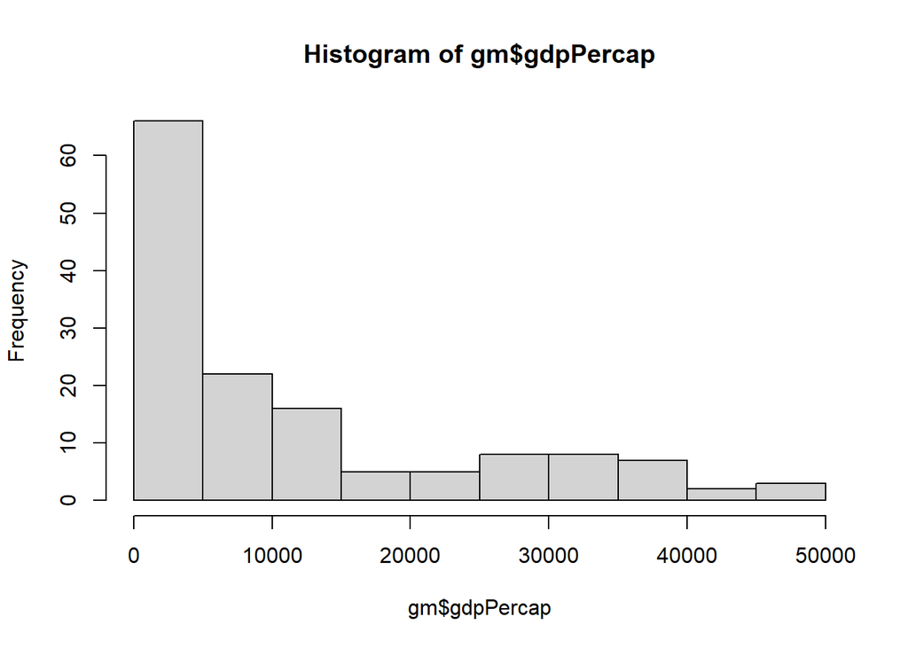

```r
hist(gm$gdpPercap)
```

Yup. We just made a histogram.

Although not all EDA is plots, it is basically making plots. Which isn’t to sell it short. We did learn a lot from this histogram that the countries GDPc is a skewed distribution with a long right tail. I have yet to see an income distribution that doesn’t look like this.

Just as a sidebar, **humans are visual creatures**. If you can say what you want in a plot, the do it in a plot.

Let’s make a scatter plot of GDP per capita vs. life expectancy. To do so, we first need to make a `formula` object to put into `plot()`.

```r
f = lifeExp ~ gdpPercap
class(f)
```

```
## [1] "formula"
```

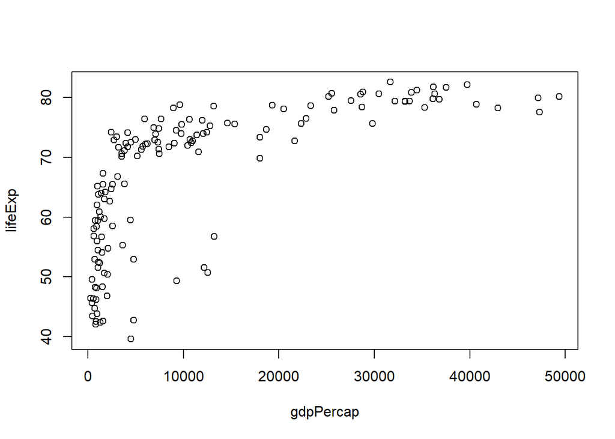

```r
plot(f, data = gm)
```

Well that is certainly an ugly plot. Let’s see if we can do any better.

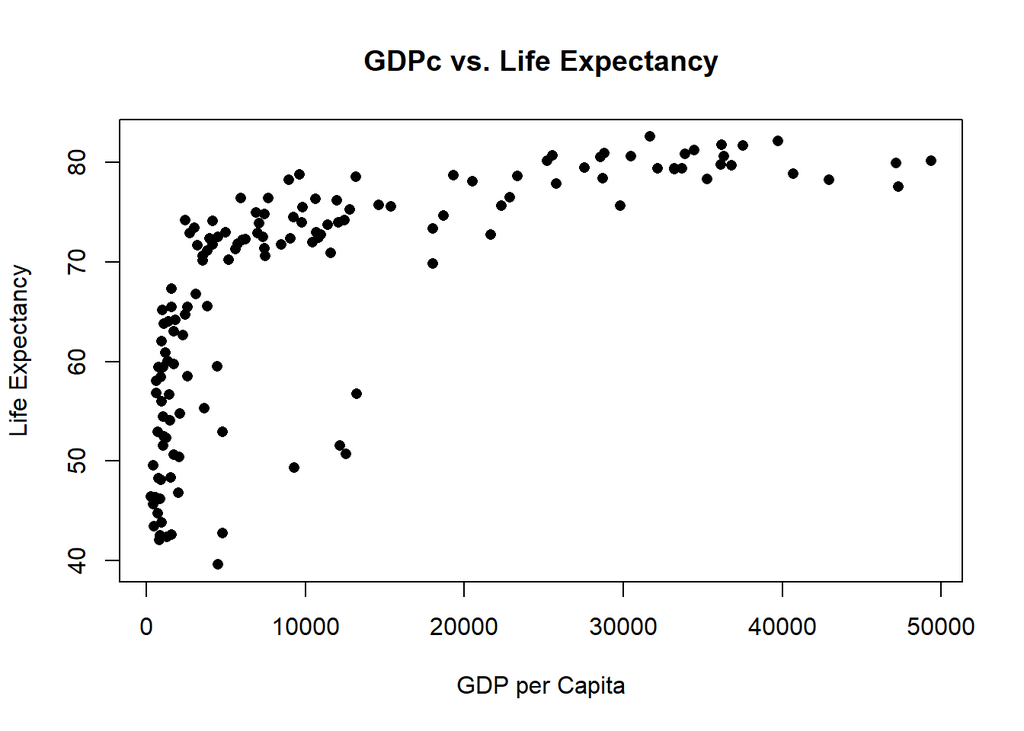

```r
plot(lifeExp ~ gdpPercap, gm,
     xlab = 'GDP per Capita', ylab = 'Life Expectancy',
     main = 'GDPc vs. Life Expectancy',
     pch = 16)
```

Well, I suppose that is a bit better but… I think we can do better.

# 7 Packages

Unfortunately, that is as good as that plot is going to get with base `R`. Fortunately, there are people out there who won’t settle for mediocracy! They will write a bundle of functions to accomplish all sorts of tasks from plotting to neural networks. Let’s stick with plotting for now.

Much like using `R`, you need to download it once, then load it every time you want to use it. We will be using the package `ggplot2` to make much better looking plots. To download or install the package, type `install.package('ggplot')`. Notice the package is in quotes. When we load the package, we don’t need to put in quotes.

```r
library(ggplot2)
```

So! On to plotting!

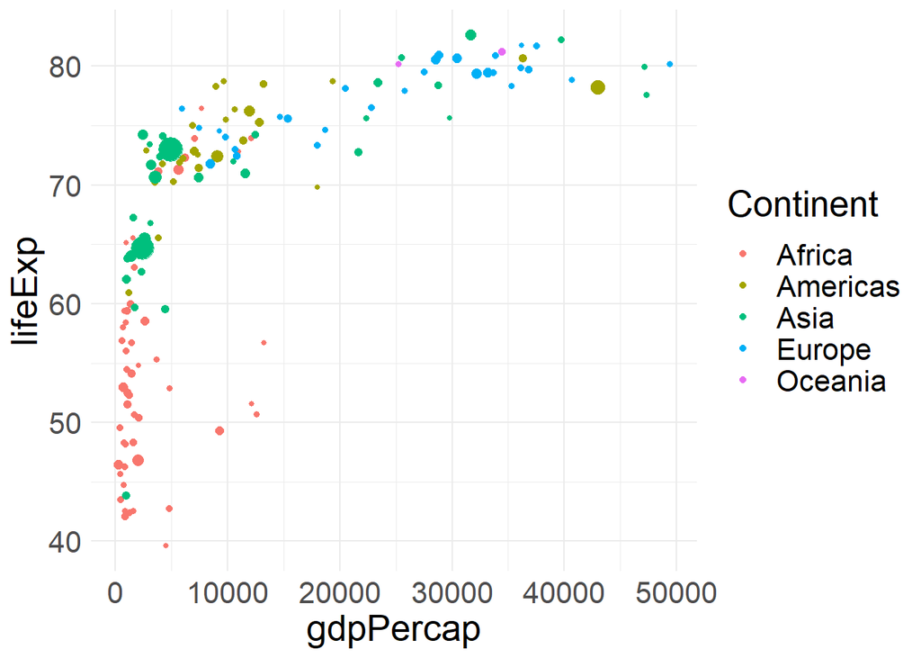

```r
ggplot(gm, aes(x = gdpPercap, y = lifeExp, color = continent, size = pop)) + #aes = aesthetics
  geom_point() + # make a scatter plot
  scale_size_continuous(guide = 'none') + # hide the legend for pop, which is a "continuous" variable
  scale_color_discrete(name = 'Continent') + # relabeling the color legend which is a "discrete" variable
  theme_minimal() + # find a black and wide theme for printing
  theme(text = element_text(size = 20)) # for easier visibility in presentations
```

Now that’s a plot!